# LUSC vs LUAD Differential Gene Expression Analysis of the PanCK positive (Cancer) cells

Claire based on Belinda/Jared code

September 09, 2025

# 1 Load libraries

```r
library(standR)
library(edgeR)
library(SpatialExperiment)
library(limma)
#library(Glimma)
library(ggrepel)
library(ggalluvial)
library(scater)
library(readxl)
library(tidyverse)
library(pheatmap)
library(statmod)
```

To ensure reproducibility, a fixed seed is set: it guarantee that the same random values are produced each time we run the code

```r
set.seed(42)
```

# 2 Load in Data

```r
# Set the directory and file name
RDataObjectsDir = "../ilaria/claires_part/rdata/"
speCancerFileName = "speCancerMIBI_GeoMx.rds"

# Read data from file
speCancer <- readRDS(file=file.path(RDataObjectsDir, speCancerFileName))
```

## 2.1 Comparisons

Starting with Sex: It is observed that the male/female ratio is much larger for LUSC

```r
table(colData(speCancer)$CancerType, colData(speCancer)$Sex)
```

```
##
##        Female Male
##   LUAD     56   66
##   LUSC     16   40
```

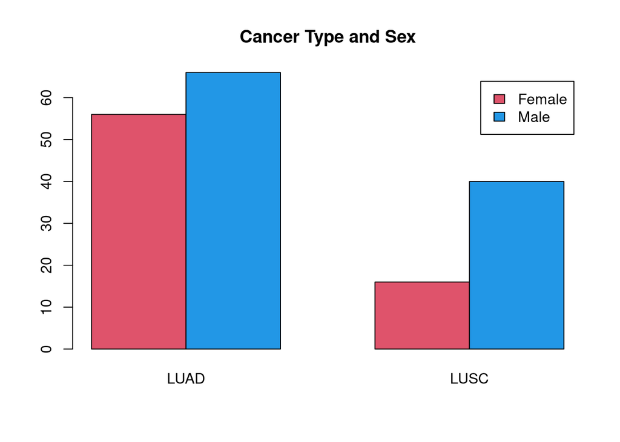

```r
barplot(table(colData(speCancer)$Sex, colData(speCancer)$CancerType), beside = TRUE, legend = TRUE, col = c(2 ,4), main = "Cancer Type and Sex")
```

Running a test of independence shows that the p-value is significant!

```r
summary(table(colData(speCancer)$CancerType, colData(speCancer)$Sex))
```

```
## Number of cases in table: 178
## Number of factors: 2
## Test for independence of all factors:
##  Chisq = 4.786, df = 1, p-value = 0.0287
```

Next, we shall look at age

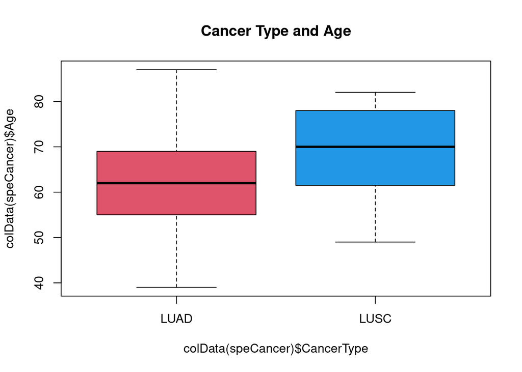

```r
boxplot(colData(speCancer)$Age ~ colData(speCancer)$CancerType, col = c(2 ,4), main = "Cancer Type and Age")
```

Running a linear model also reveals a significant correlation between CancerType and Age

```r
summary(lm(colData(speCancer)$Age ~ colData(speCancer)$CancerType))
```

```
##
## Call:
## lm(formula = colData(speCancer)$Age ~ colData(speCancer)$CancerType)
##
## Residuals:
##      Min       1Q   Median       3Q      Max
## -22.3361  -6.3361   0.9821   7.6639  25.6639
##
## Coefficients:
##                                   Estimate Std. Error t value Pr(>|t|)
## (Intercept)                        61.3361     0.9272  66.151  < 2e-16 ***
## colData(speCancer)$CancerTypeLUSC   7.6818     1.6531   4.647 6.58e-06 ***
## ---
## Signif. codes:  0 '***' 0.001 '**' 0.01 '*' 0.05 '.' 0.1 ' ' 1
##
## Residual standard error: 10.24 on 176 degrees of freedom
## Multiple R-squared:  0.1093, Adjusted R-squared:  0.1042
## F-statistic: 21.59 on 1 and 176 DF,  p-value: 6.582e-06
```

Next, we shall look at Smoking Status.

The most notable observation is that there are 0 never-smokers with LUSC. This makes smoking status not suitable for the design matrix, and there will be issues running a test of significant on this because of the 0 entry.

```r
table(colData(speCancer)$CancerType, colData(speCancer)$SmokingStatus)
```

```
##
##        CS ES not cited NS
##   LUAD 13 30        62 17
##   LUSC  6 15        35  0
```

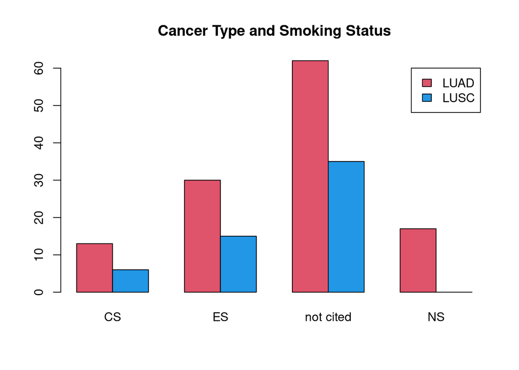

```r
barplot(table(colData(speCancer)$CancerType, colData(speCancer)$SmokingStatus), beside = TRUE, legend = TRUE, col = c(2 ,4), main = "Cancer Type and Smoking Status")
```

# 3 TMM normalization

The next step is to undergo normalisation. TMM is used in the analysis

Normalise using the standR function `geomxNorm`

```r
spe_tmm_cancer <- geomxNorm(speCancer, method = "TMM")
```

Convert to DGE object for Differential Gene Expression Analysis

```r
dgeCancer <- SE2DGEList(spe_tmm_cancer)
```

Copy over the norm factors manually as the norm.factors are not copied over by default

```r
dgeCancer$samples$norm.factors <- metadata(spe_tmm_cancer)$norm.factor
```

Visualize the counts to ensure that normalisation worked properly.

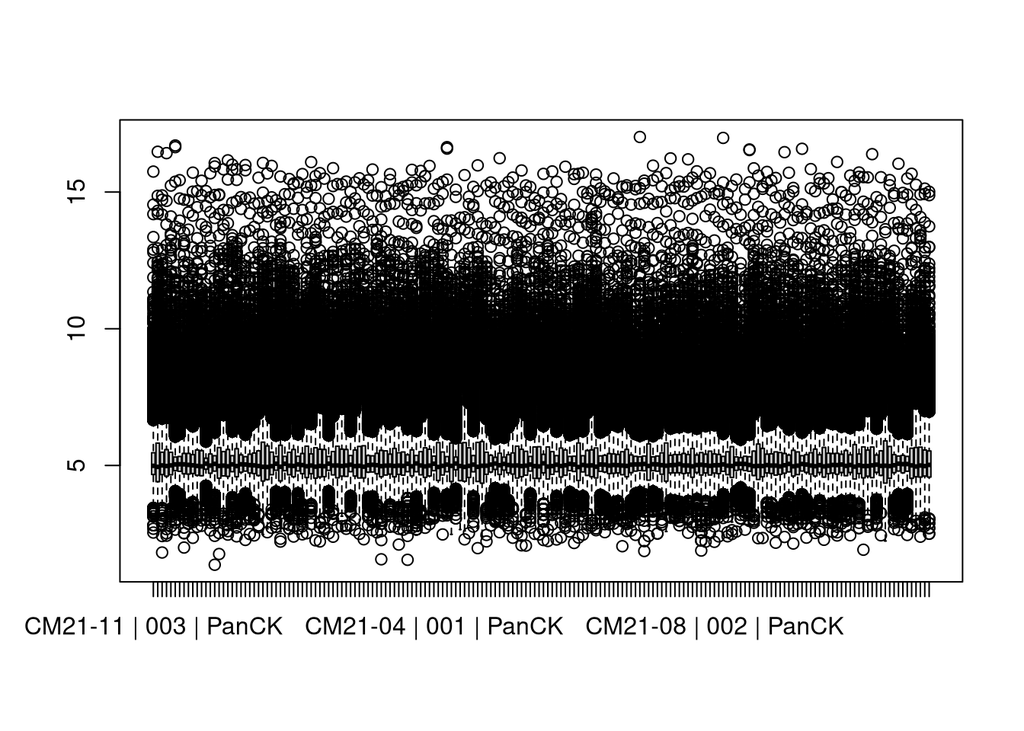

```r
logcountsCancer <- cpm.DGEList(dgeCancer, log=TRUE)
boxplot(logcountsCancer)
```

View the RLE plot as well to ensure the samples are good.

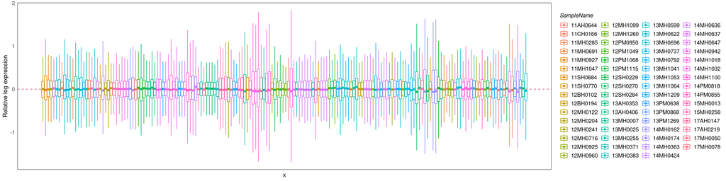

```r
plotRLExpr(spe_tmm_cancer, ordannots = "SlideName", assay = "logcounts", col = SampleName)
```

# Normalised Data Visualisation Through Dimensional Reduction Analysis (MDS)

First, start by looking at the MDS coloured by cancer type. It is worth noting that there are blue dots within the Red cluster. Double check to ensure the cancer is not mislabeled.

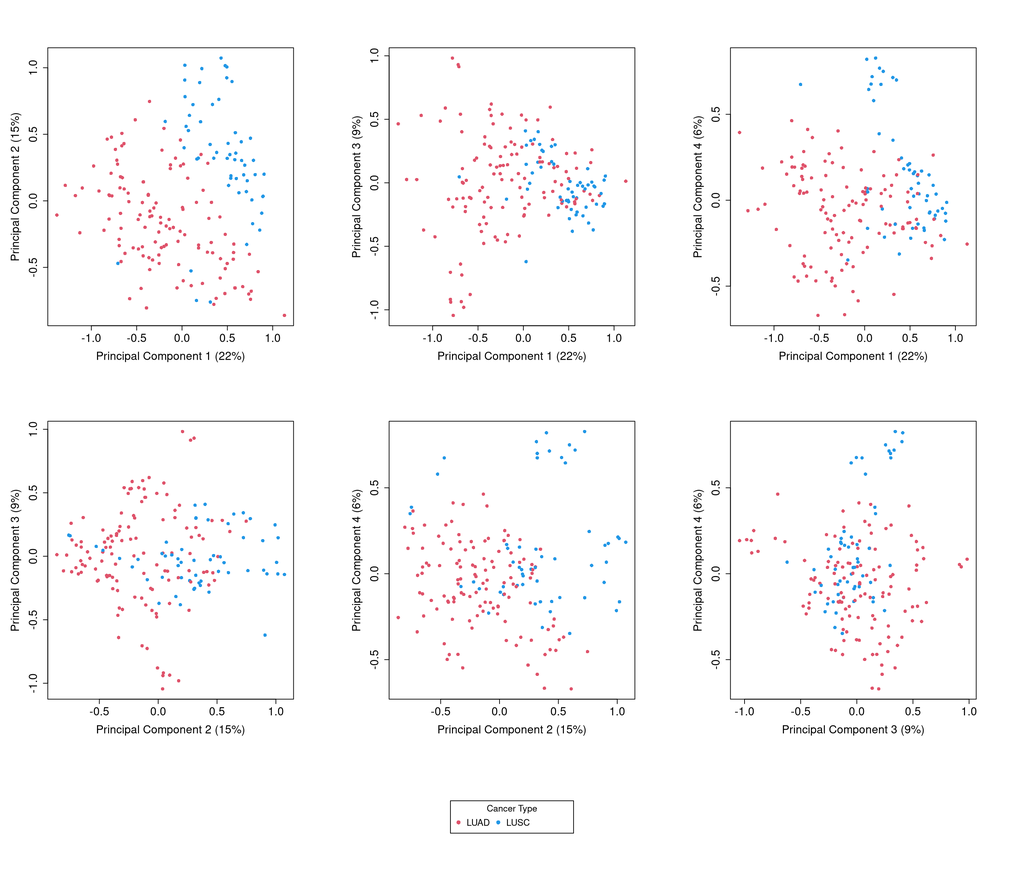

```r
#par(mfrow = c(3,3))

layout(matrix(c(1,2,3,4,5,6,7,7,7), ncol=3, byrow=TRUE), heights=c(4, 4, 1.5))
par(cex.axis = 1.5)
par(cex.lab = 1.5)
par(mai=rep(0.7, 4))

PC12 <- plotMDS.DGEList(dgeCancer, pch = 16, col = c(2,4)[factor(dgeCancer$samples$CancerType)], gene.selection = "common")
plotMDS.DGEList(dgeCancer, pch = 16, col = c(2,4)[factor(dgeCancer$samples$CancerType)], gene.selection = "common", dim = c(1,3))
plotMDS.DGEList(dgeCancer, pch = 16, col = c(2,4)[factor(dgeCancer$samples$CancerType)], gene.selection = "common", dim = c(1,4))
plotMDS.DGEList(dgeCancer, pch = 16, col = c(2,4)[factor(dgeCancer$samples$CancerType)], gene.selection = "common", dim = c(2,3))
plotMDS.DGEList(dgeCancer, pch = 16, col = c(2,4)[factor(dgeCancer$samples$CancerType)], gene.selection = "common", dim = c(2,4))
plotMDS.DGEList(dgeCancer, pch = 16, col = c(2,4)[factor(dgeCancer$samples$CancerType)], gene.selection = "common", dim = c(3,4))
plot.new()
legend(x="center", ncol=3, legend = levels(factor(dgeCancer$samples$CancerType)), col = c(2,4), pch = 16, title="Cancer Type", cex = 1.2)
```

Next is to color the data by Sex

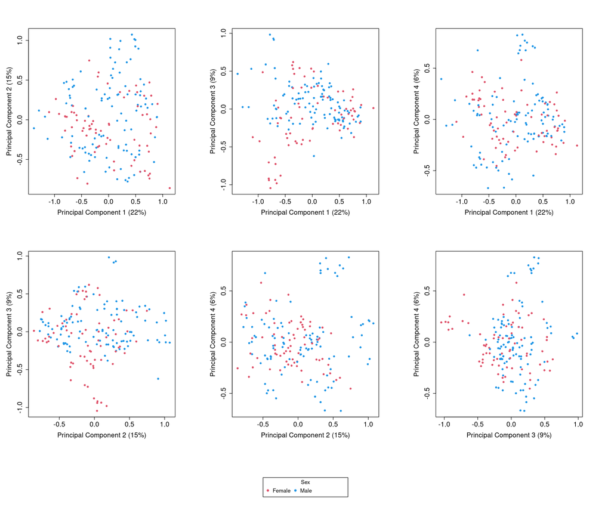

```r
#par(mfrow = c(3,3))

layout(matrix(c(1,2,3,4,5,6,7,7,7), ncol=3, byrow=TRUE), heights=c(4, 4, 1.5))
par(cex.axis = 1.5)
par(cex.lab = 1.5)
par(mai=rep(0.7, 4))

plotMDS.DGEList(dgeCancer, pch = 16, col = c(2,4)[factor(dgeCancer$samples$Sex)], gene.selection = "common")
plotMDS.DGEList(dgeCancer, pch = 16, col = c(2,4)[factor(dgeCancer$samples$Sex)], gene.selection = "common", dim = c(1,3))
plotMDS.DGEList(dgeCancer, pch = 16, col = c(2,4)[factor(dgeCancer$samples$Sex)], gene.selection = "common", dim = c(1,4))
plotMDS.DGEList(dgeCancer, pch = 16, col = c(2,4)[factor(dgeCancer$samples$Sex)], gene.selection = "common", dim = c(2,3))
plotMDS.DGEList(dgeCancer, pch = 16, col = c(2,4)[factor(dgeCancer$samples$Sex)], gene.selection = "common", dim = c(2,4))
plotMDS.DGEList(dgeCancer, pch = 16, col = c(2,4)[factor(dgeCancer$samples$Sex)], gene.selection = "common", dim = c(3,4))
plot.new()
legend(x="center", ncol=3, legend = levels(factor(dgeCancer$samples$Sex)), col = c(2,4), pch = 16, title="Sex", cex = 1.2)
```

Despite not modelling Smoking status, lets see if there’s any grouping. There is a noticeable grouping of non-smokers

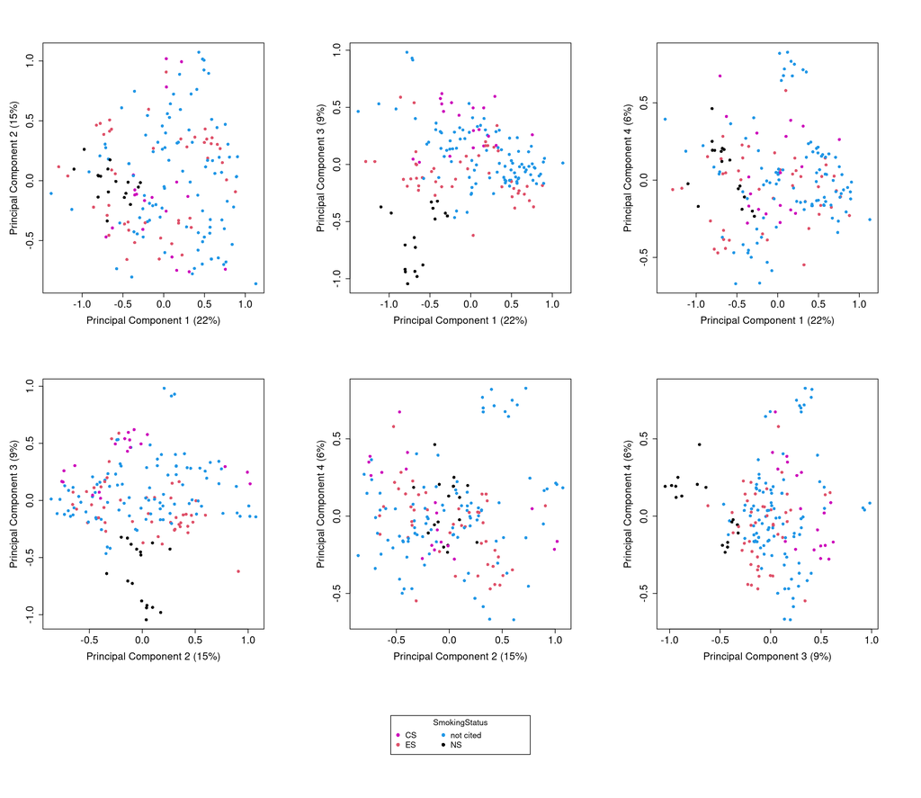

```r
#par(mfrow = c(3,3))

layout(matrix(c(1,2,3,4,5,6,7,7,7), ncol=3, byrow=TRUE), heights=c(4, 4, 1.5))
par(cex.axis = 1.5)
par(cex.lab = 1.5)
par(mai=rep(0.7, 4))

plotMDS.DGEList(dgeCancer, pch = 16, col = c(14,2,4,1)[factor(dgeCancer$samples$SmokingStatus)], gene.selection = "common")
plotMDS.DGEList(dgeCancer, pch = 16, col = c(14,2,4,1)[factor(dgeCancer$samples$SmokingStatus)], gene.selection = "common", dim = c(1,3))
plotMDS.DGEList(dgeCancer, pch = 16, col = c(14,2,4,1)[factor(dgeCancer$samples$SmokingStatus)], gene.selection = "common", dim = c(1,4))
plotMDS.DGEList(dgeCancer, pch = 16, col = c(14,2,4,1)[factor(dgeCancer$samples$SmokingStatus)], gene.selection = "common", dim = c(2,3))
plotMDS.DGEList(dgeCancer, pch = 16, col = c(14,2,4,1)[factor(dgeCancer$samples$SmokingStatus)], gene.selection = "common", dim = c(2,4))
plotMDS.DGEList(dgeCancer, pch = 16, col = c(14,2,4,1)[factor(dgeCancer$samples$SmokingStatus)], gene.selection = "common", dim = c(3,4))
plot.new()
legend(x="center", ncol=3, legend = levels(factor(dgeCancer$samples$SmokingStatus)), col = c(14,2,4,1), pch = 16, title="SmokingStatus", cex = 1.2)
```

For slide year, there may be a noticeable difference between Sample Year 12 and 13

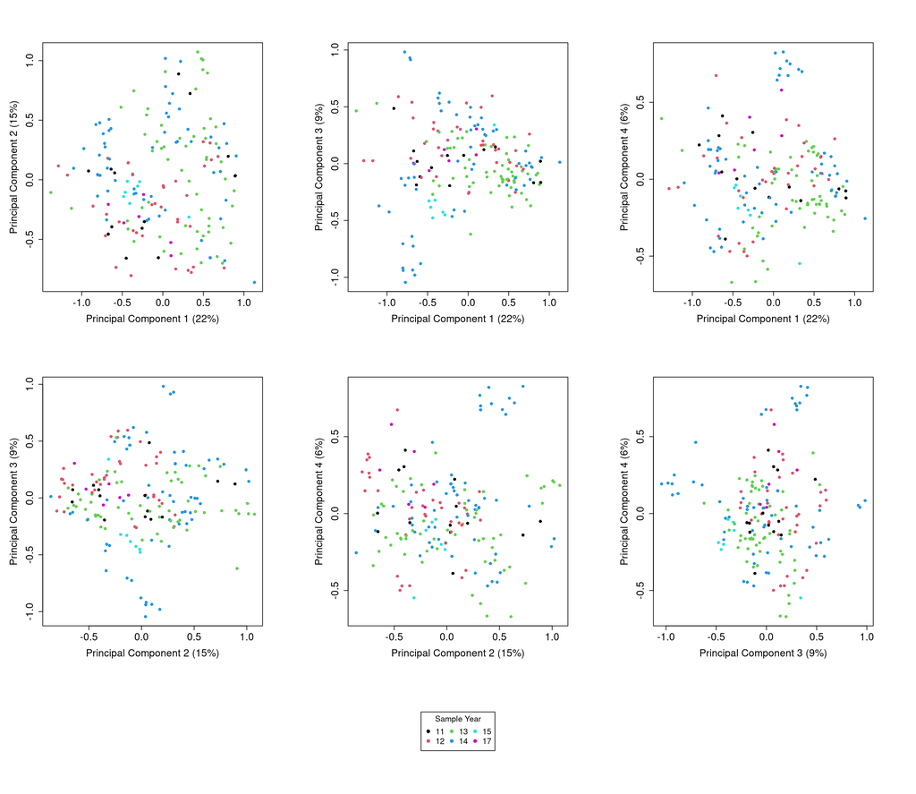

```r
#par(mfrow = c(3,3))

layout(matrix(c(1,2,3,4,5,6,7,7,7), ncol=3, byrow=TRUE), heights=c(4, 4, 1.5))
par(cex.axis = 1.5)
par(cex.lab = 1.5)
par(mai=rep(0.7, 4))

plotMDS.DGEList(dgeCancer, pch = 16, col = c(1:6)[factor(dgeCancer$samples$SampleYear)], gene.selection = "common")
plotMDS.DGEList(dgeCancer, pch = 16, col = c(1:6)[factor(dgeCancer$samples$SampleYear)], gene.selection = "common", dim = c(1,3))
plotMDS.DGEList(dgeCancer, pch = 16, col = c(1:6)[factor(dgeCancer$samples$SampleYear)], gene.selection = "common", dim = c(1,4))
plotMDS.DGEList(dgeCancer, pch = 16, col = c(1:6)[factor(dgeCancer$samples$SampleYear)], gene.selection = "common", dim = c(2,3))
plotMDS.DGEList(dgeCancer, pch = 16, col = c(1:6)[factor(dgeCancer$samples$SampleYear)], gene.selection = "common", dim = c(2,4))
plotMDS.DGEList(dgeCancer, pch = 16, col = c(1:6)[factor(dgeCancer$samples$SampleYear)], gene.selection = "common", dim = c(3,4))
plot.new()
legend(x="center", ncol=3, legend = levels(factor(dgeCancer$samples$SampleYear)), col = c(1:6), pch = 16, title="Sample Year", cex = 1.2)
```

# DGE Analysis Cancer

```r
designCancer <- model.matrix(~ factor(dgeCancer$samples$CancerType) + dgeCancer$samples$Age + factor (dgeCancer$samples$Sex))
head(designCancer)
```

```
##   (Intercept) factor(dgeCancer$samples$CancerType)LUSC dgeCancer$samples$Age
## 1           1                                        0                    65
## 2           1                                        0                    66
## 3           1                                        0                    55
## 4           1                                        0                    71
## 5           1                                        0                    55
## 6           1                                        0                    46
##   factor(dgeCancer$samples$Sex)Male
## 1                                 1
## 2                                 1
## 3                                 0
## 4                                 0
## 5                                 0
## 6                                 1
```

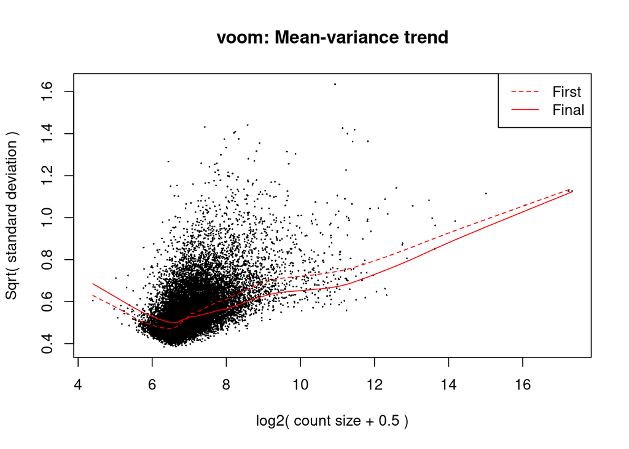

```r
par(mfrow=c(1,1))
vCancer <- voomLmFit(dgeCancer, designCancer, plot = TRUE, span = 0.05, block = dgeCancer$samples$SampleName,normalize.method="cyclicloess")
```

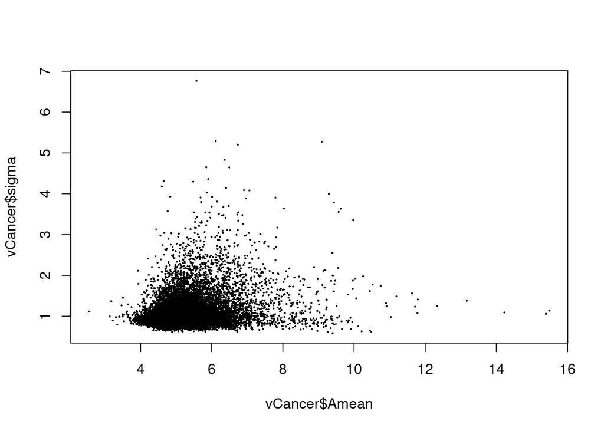

```r
plot(vCancer$Amean, vCancer$sigma, pch=16, cex=0.3)
```

```r
fitCancer <- eBayes(vCancer, robust = TRUE)
```

```r
dim(fitCancer)
```

```
## [1] 18676     4
```

```r
summa.fitCancer <- decideTests(fitCancer)
summary(summa.fitCancer)
```

```
##        (Intercept) factor(dgeCancer$samples$CancerType)LUSC
## Down             0                                     1688
## NotSig           0                                    15311
## Up           18676                                     1677
##        dgeCancer$samples$Age factor(dgeCancer$samples$Sex)Male
## Down                       3                                 3
## NotSig                 18668                             18660
## Up                         5                                13
```

# 4 Treat analysis (only for this whole analysis where we have a lot of DGE)

```r
tfitCancer <- treat(fitCancer, fc=1.1)
```

```r
summa.tfitCancer <- decideTests(tfitCancer)
summary(summa.tfitCancer)
```

```
##        (Intercept) factor(dgeCancer$samples$CancerType)LUSC
## Down             0                                      374
## NotSig           0                                    17971
## Up           18676                                      331
##        dgeCancer$samples$Age factor(dgeCancer$samples$Sex)Male
## Down                       0                                 0
## NotSig                 18676                             18670
## Up                         0                                 6
```

```r
ResultTreatedCancer <- topTable(tfitCancer, coef = 2, sort.by = "p", n = Inf)
topGenesTreatedCancer <- topTable(tfitCancer, coef = 2, sort.by = "p", n = Inf, p.value = 0.05)
```

Remove columns as some are not of interest in this analysis

```r
ResultTreatedCancer <- subset(ResultTreatedCancer, select = c(logFC, AveExpr, t, P.Value, adj.P.Val))
topGenesTreatedCancer <- subset(topGenesTreatedCancer, select = c(logFC, AveExpr, t, P.Value, adj.P.Val))
```

Ensure that a directory is created

```r
# Create directory if it does not exist
if (!dir.exists("results")) {
  dir.create("results", recursive = TRUE)
}
```

```r
write.csv(ResultTreatedCancer, file = "../output/Fig2/ResultLUSCvsLUADTreatedCancerAll.csv")
write.csv(topGenesTreatedCancer, file = "../output/Fig2/topSigResultLUSCvsLUADTreatedCancerAll.csv")
```

# 5 Plot Results

```r
library(ggplot2)
library(dplyr)
library(ggrepel)

# Create the DE column first
ResultTreatedCancer <- ResultTreatedCancer %>%
  mutate(DE = ifelse(logFC > 0.5 & adj.P.Val < 0.05, "UP",
                    ifelse(logFC < -0.5 & adj.P.Val < 0.05, "DOWN", "NOT DE")))

# Filter data for "UP" and "DOWN" genes
filtered_data <- ResultTreatedCancer %>%
  filter(DE %in% c("UP", "DOWN")) %>%
  mutate(Gene = rownames(.))

# Filter data for specific genes
highlighted_genes <- c("TP63", "NKX2.1", "KRT7", "MUC1", "SFTPB", "KRT5", "KRT6A")
highlighted_data <- filtered_data %>% filter(Gene %in% highlighted_genes)

# Filter out genes that are already in highlighted_data
unhighlighted_data <- filtered_data %>% anti_join(highlighted_data, by = "Gene")

# Now create the plot and use the filtered data for geom_text_repel
MDPlotCancer <- ggplot(ResultTreatedCancer, aes(AveExpr, logFC, col = DE)) +
  geom_point(shape = 16, size = 1) +
  geom_text_repel(data = unhighlighted_data, aes(label = Gene), show.legend = FALSE,
                  nudge_x = 0.5,  # Adjust the nudge along the x-axis
                  nudge_y = 0.5,  # Adjust the nudge along the y-axis
                  box.padding = 0.5,
                  max.overlaps = 30,  # Keep max.overlaps at 50
                  segment.size = 0.2,  # add a segment between text and point
                  segment.color = "black") +
  geom_text_repel(data = highlighted_data,
                 aes(label = Gene),
                 nudge_x = -2,  # Adjust the nudge along the x-axis
                  nudge_y = 0.1,  # Adjust the nudge along the y-axis
                 show.legend = FALSE,
                 box.padding = 0.5,
                 max.overlaps = Inf,  # Set max.overlaps to Inf for specific genes
                 segment.size = 0.2,  # add a segment between text and point
                 fontface = "bold") +  # Bold labels for specific genes
  theme_bw() +
  xlab("Average log-expression") +
  ylab("Log-fold-change") +
  ggtitle("LUSC vs LUAD for PanCK (limma-voom)") +
  scale_color_manual(values = c("blue", "grey", "red")) +
  theme(text = element_text(size = 12, family = "Helvetica"))
```

Visualise MD Plot

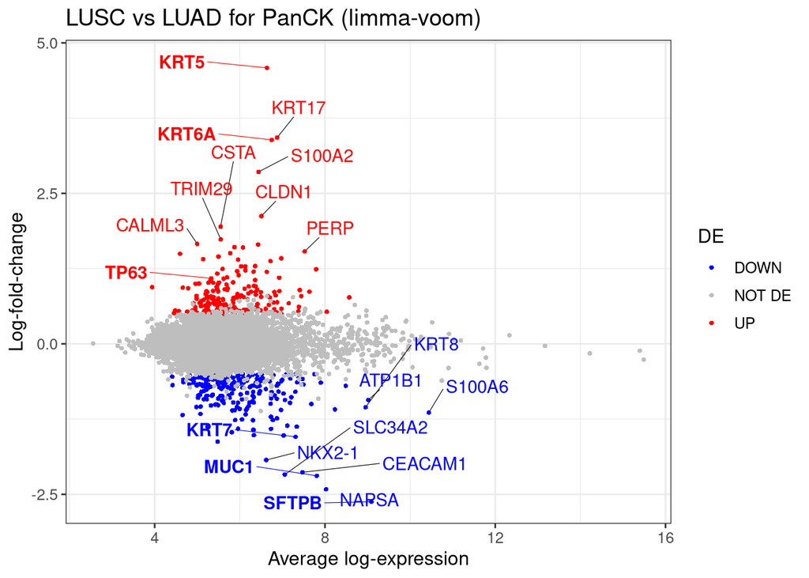

```r
MDPlotCancer
```

Save MD Plot

```r
pdf(file="results/cancerLUSCvsLUADMDPlotAdjPValue-final.pdf",width=8,height=5,onefile = FALSE)
MDPlotCancer
dev.off()
```

##### 5.0.0.0.1 Heatmap for 100top genes

take the 100 top genes

```r
Top100genesCancer <- topTable(tfitCancer, sort.by = "p" ,coef=2, n=100, lfc = 0.5)
```

```r
countsTop100genes <- tfitCancer$EList$E[rownames(Top100genesCancer),]
```

```r
dgeCancerTop100genes <- dgeCancer$samples[colnames(countsTop100genes),]
CancerType <- data.frame(dgeCancerTop100genes$Sex, dgeCancerTop100genes$CancerType)
row.names(CancerType) <- rownames(dgeCancerTop100genes)
```

#heatmap

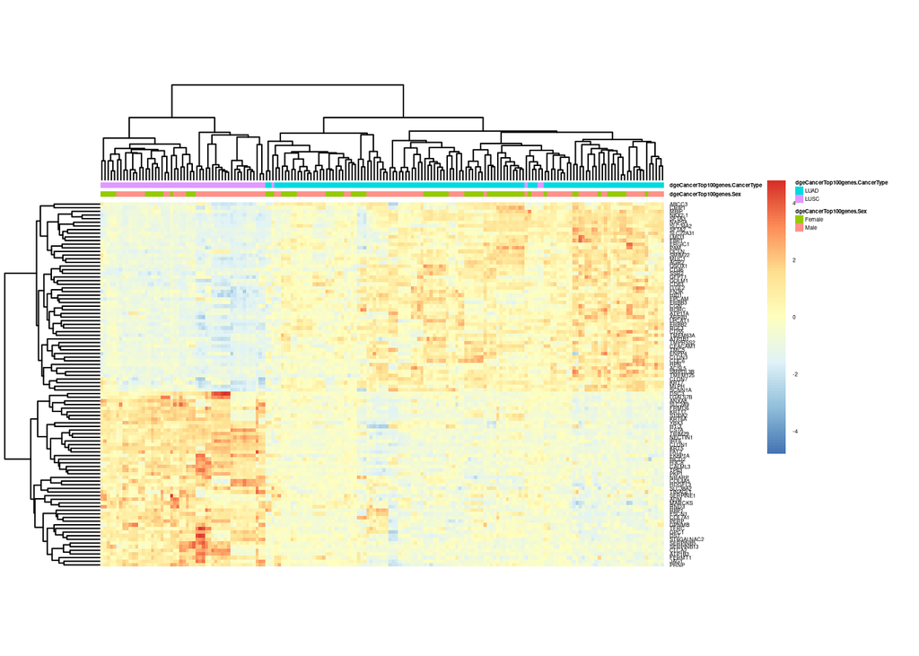

```r
pheatmap (countsTop100genes,
          scale = "row",
          fontsize = 3,
          cellheight = 2,
          show_colnames = FALSE,
          annotation_col = CancerType,
          #filename = "../output/Fig2/cancerTop100genes-LUADLUSC-Heatmap.pdf"
          )
```

##### Heatmap for 50top genes

take the 50 top genes

```r
Top50genesCancer <- topTable(tfitCancer, sort.by = "p" ,coef=2, n=50, lfc = 0.5)
```

```r
countsTop50genes <- tfitCancer$EList$E[rownames(Top50genesCancer),]
```

```r
dgeCancerTop50genes <- dgeCancer$samples[colnames(countsTop50genes),]
CancerType <- data.frame(dgeCancerTop50genes$Sex, dgeCancerTop50genes$CancerType)
row.names(CancerType) <- rownames(dgeCancerTop50genes)
```

#heatmap

```r
pheatmap (countsTop50genes,
          scale = "row",
          fontsize = 2,
          extra_font = c("Helvetica"),
          cellheight = 2,
          show_colnames = FALSE,
          annotation_col = CancerType,
          filename = "results/cancerTop50genes-LUADLUSC-Heatmap-2.pdf"
          )
```

##### 5.0.0.0.2 Heatmap for 20top and 20down genes

```r
Top20genesCancer <- topTable(tfitCancer, sort.by = "p" ,coef=2, n=20, lfc = 0.5)
Down20genesCancer <- topTable(tfitCancer, sort.by = "p" ,coef=2, n=20, lfc = -0.5)
```

```r
countsTop20genes <- tfitCancer$EList$E[rownames(Top20genesCancer),]
countsDown20genes <- tfitCancer$EList$E[rownames(Down20genesCancer),]
countsCombined<- cbind(countsTop20genes,countsDown20genes)
```

```r
dgeCancerTop20genes <- dgeCancer$samples[colnames(countsTop20genes),]
dgeCancerDown20genes <- dgeCancer$samples[colnames(countsDown20genes),]
combined<- cbind (dgeCancerTop20genes, dgeCancerDown20genes)
CancerType <- data.frame(combined$Sex,combined$CancerType)
row.names(CancerType) <- rownames(combined)
```

#heatmap

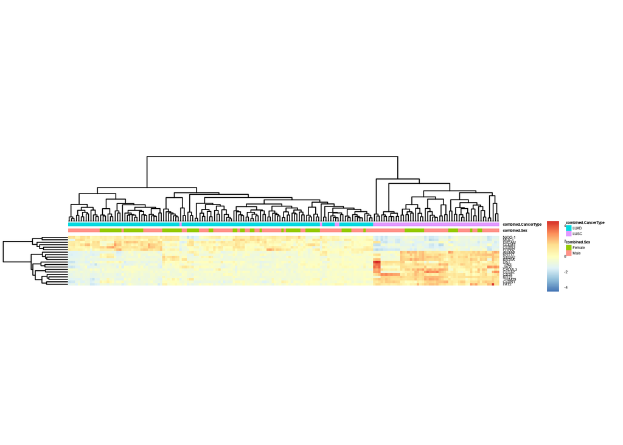

```r
pheatmap (countsCombined,
          scale = "row",
          fontsize = 3,
          cellheight = 2,
          show_colnames = FALSE,
          annotation_col = CancerType,
          #filename = "../output/Fig2/cancerTop20Down20genes-LUADLUSC-Heatmap.pdf"
          )
```